# Reproducible Research: Peer Assessment 1

### 7.1 Histogram of the total number of steps taken each day after missing values are imputed

The 7th question has been split in two. The first part is to show the creation of the aggregated dat, and to show the original and new histograms together

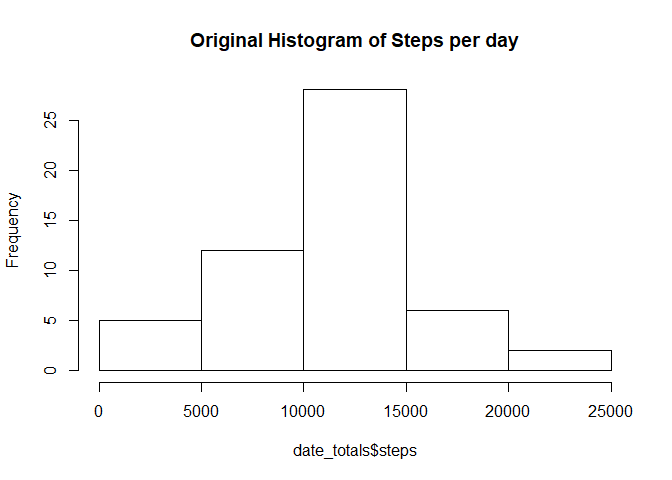

```r
##Do the same analysis but with missing values replaced
date_totals2 <- aggregate(steps ~ date, data = activity_data2,FUN = "sum")
date_totals2$date <- as.Date(date_totals2$date, "%Y-%m-%d")

#show histrogram of total steps per day
hist(date_totals$steps, main = "Original Histogram of Steps per day")
```

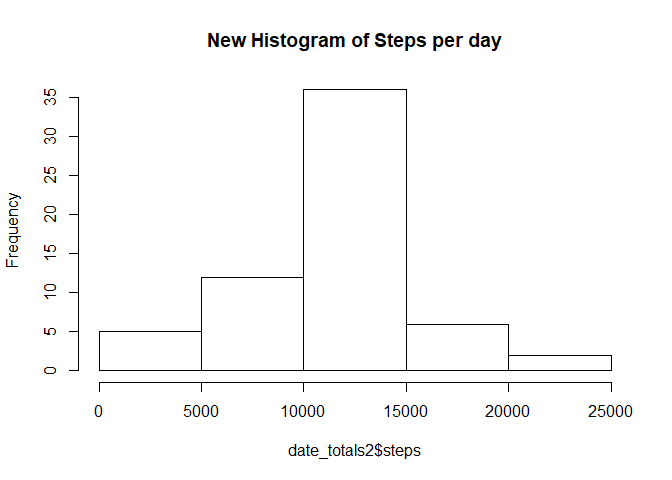

```r
hist(date_totals2$steps, main = "New Histogram of Steps per day")
```

###7.2 Mean and Median Report the mean and median total number of steps taken per day. Do these values differ from the estimates from the first part of the assignment? What is the impact of imputing missing data on the estimates of the total daily number of steps?

```r
#mean steps per day
newmean <- mean(date_totals2$steps)
#median steps per day
newmedian <- median(date_totals2$steps)

print("Means")
```

```
## [1] "Means"
```

```r
print(newmean)
```

```
## [1] 10766.19
```

```r
print(summ[4])
```

```
##  Mean
## 10770
```

```r
print("Medians")
```

```
## [1] "Medians"
```

```r
print(newmedian)
```

```
## [1] 10766.19
```

```r
print(summ[3])
```

```
## Median
##  10760
```

## Are there differences in activity patterns between weekdays and weekends?

### 8.1 Create a new factor variable in the dataset with two levels - “weekday” and “weekend” indicating whether a given date is a weekday or weekend day.

The below chunk takes the data in the dataset, calculates the day of the week if was, and then does an if else function to decide if that day was the weekend or not. It then aggregates by this new level along with interval so we can see average steps per interbal by weekday or weekend.

```r
activity_data2 <- activity_data2 %>%
    mutate(weekdayFlag = ifelse(weekdays(as.Date(date, "%Y-%m-%d")) %in% c("Saturday","Sunday"),
                                         "Weekend",
                                         "Weekday"))

wd_data <- aggregate(steps ~ interval + weekdayFlag, data = activity_data2, FUN = "mean")
```

### 8.2 Panel plot comparing the average number of steps taken per 5-minute interval across weekdays and weekends

The last step is to show plots comparing weekend and weekdays. The main difference visible is that during the weekdays there is a noticibable spike in the morning, with the remainder of the day at a much lower pace. The weekend does not have such a dominating peak in the morning, but the remainder of the day is generally more active than the weekdays.

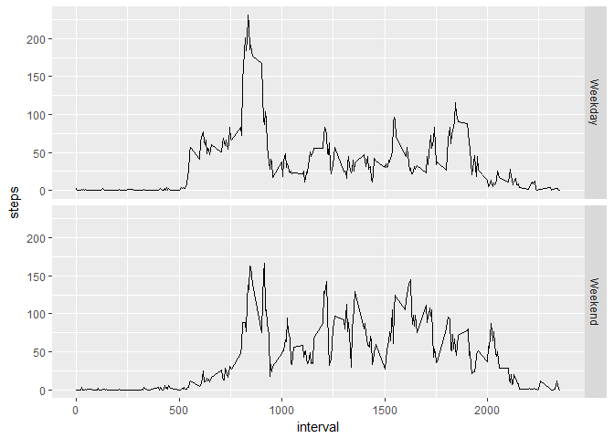

```r
ggplot(wd_data, aes(interval, steps))+
    geom_line(stat = "identity")+
    facet_grid(weekdayFlag~.)
```